# Fun with R: Ecological data analysis in R

Vianney Denis

2020/10/20

# **Topic 4 - Make a map**

Current solutions for creating maps usually involves GIS software, such as ArcGIS, QGIS, eSpatial, etc., which allow to visually prepare a map, in the same approach as one would prepare a poster or a document layout. On the other hand, R has also advanced spatial capabilities and can be used to draw maps. As we mentioned earlier, you can customize easily a map as you wish.

## `maptools` and `rgdal` packages

### Simple map

Getting a simple map is pretty straightforward in R using the package`maptools`

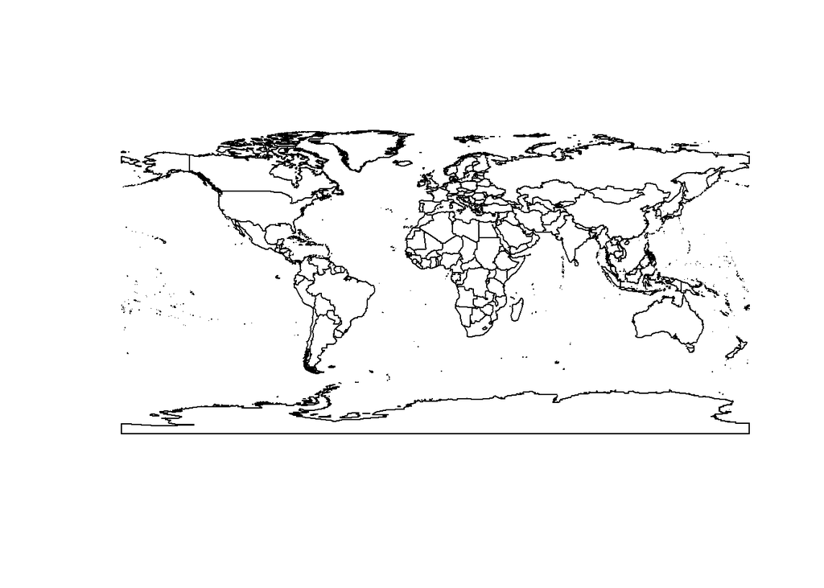

```r
library('maptools')
data(wrld_simpl)
plot(wrld_simpl)
```

Now we know the options to modify a plot, therefore you can customize this map with some elements we mentioned earlier:

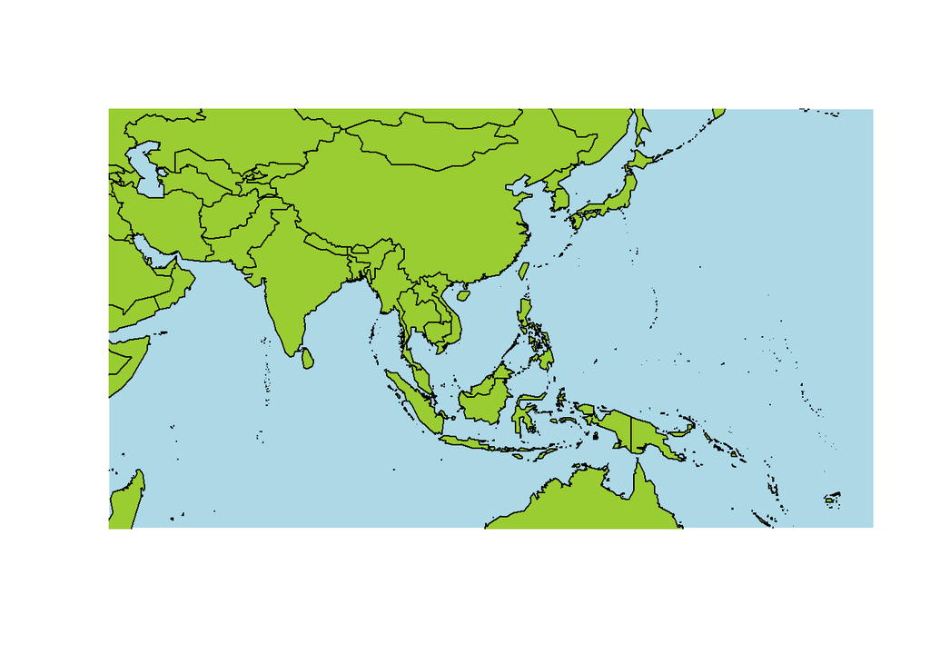

```r
plot(wrld_simpl,xlim=c(100,130),ylim=c(-20,50),col='olivedrab3',bg='lightblue')
```

Try to zoom on Taiwan: you will quickly realize that we have a pretty bad resolution a finer scale, see `?wrld_simpl`

### GPS: data tracking

If you like running, hiking, walking, or being lazy in a park - many devices now can export `gpx` format. You an read the file directly as lines (i.e, `tracks`), points (i.e, `track_points`), and a few other formats you can find in the help for `readOGR`.

```r
library(rgdal)
par(mfrow=c(1,2))
run1 <- readOGR(dsn="Data/run.gpx",layer="tracks")
```

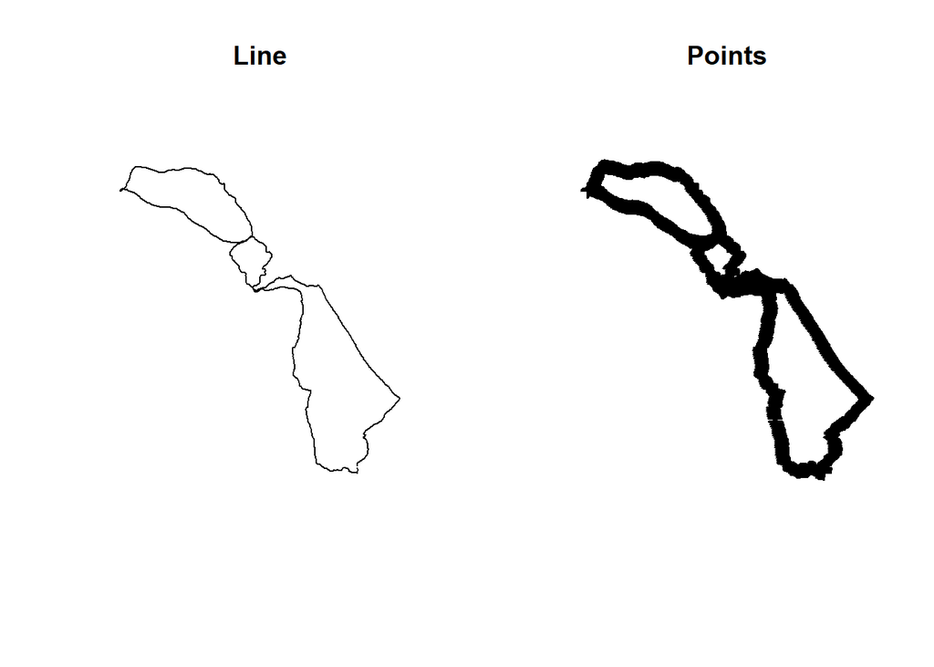

```r
plot(run1, main='Line') # my running activity
run2 <- readOGR(dsn="Data/run.gpx",layer="track_points")
plot(run2, main='Points')
```

```r
dev.off()
```

The reverse can be accomplish with the function `writeOGR` to export objects as SpatialPointsDataFrame, SpatialLinesDataFrame, or SpatialPolygonsDataFrame (as defined in the `sp` package). This will write an ArcGIS compatible shapefile, but many different formats are available by specyfying the correct driver.Now that we know how to get a super basic map in R, let’s look at how we can export and import data.

```r
writeOGR(wrld_simpl,dsn="Data", layer = "world_test", driver = "ESRI Shapefile", overwrite_layer = TRUE)
```

Now we could open `world_test.shp` in ArcGIS (or others), but we can also import shapefiles (.shp) back into R, let’s use that same file

```r
world_shp <- readOGR(dsn = "Data",layer = "world_test")
```

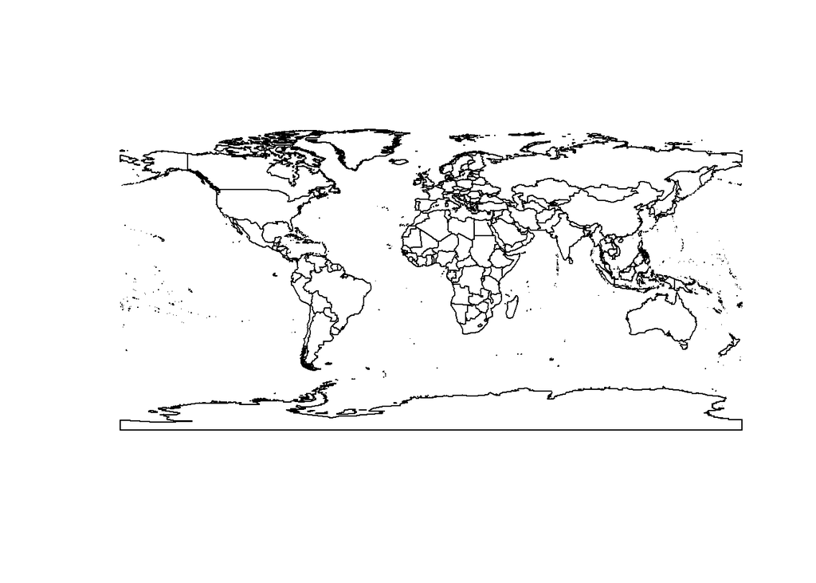

```r
plot(world_shp)
```

## Spatial data types

#### Vector based (points, Lines, polygones)

Creating spatial data from scratch in R seems a little bit confusing at first, but once you got the logic behind, it get easier:

- `SpatialPointsDataFrame` for plotting points

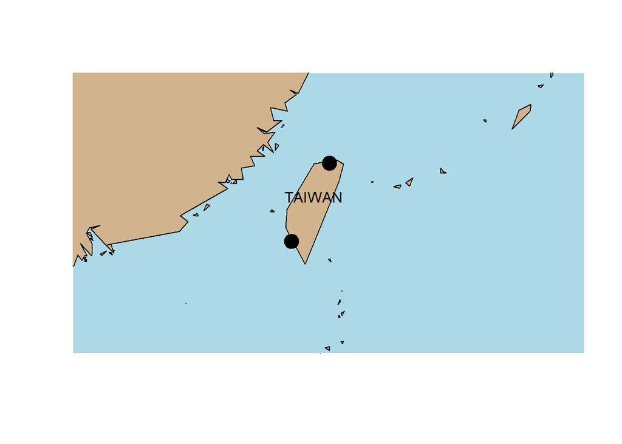

```r
plot(wrld_simpl,xlim=c(115,128) ,ylim=c(19.5,27.5),col='#D2B48C',bg='lightblue') # TW map
coords <- matrix(c(121.537290,120.265541, 25.021335, 22.626524),ncol=2) # NTU and SYS univ.
coords <- coordinates(coords) # assign values as spatial coordinates
spoints <- SpatialPoints(coords) # create SpatialPoints
df <- data.frame(location=c("NTU","SYS")) # create a dataframe
spointsdf <- SpatialPointsDataFrame(spoints,df) # create a SpatialPointsDataFrame
plot(spointsdf,add=T,col=c('black','black'),pch=19,cex=2.2) # plot it on our map
text(121,24, 'TAIWAN', cex=1)
```

- `SpatialLinesDataFrame` for plotting lines: let’s travel in Canada in the province of Saskatchewan

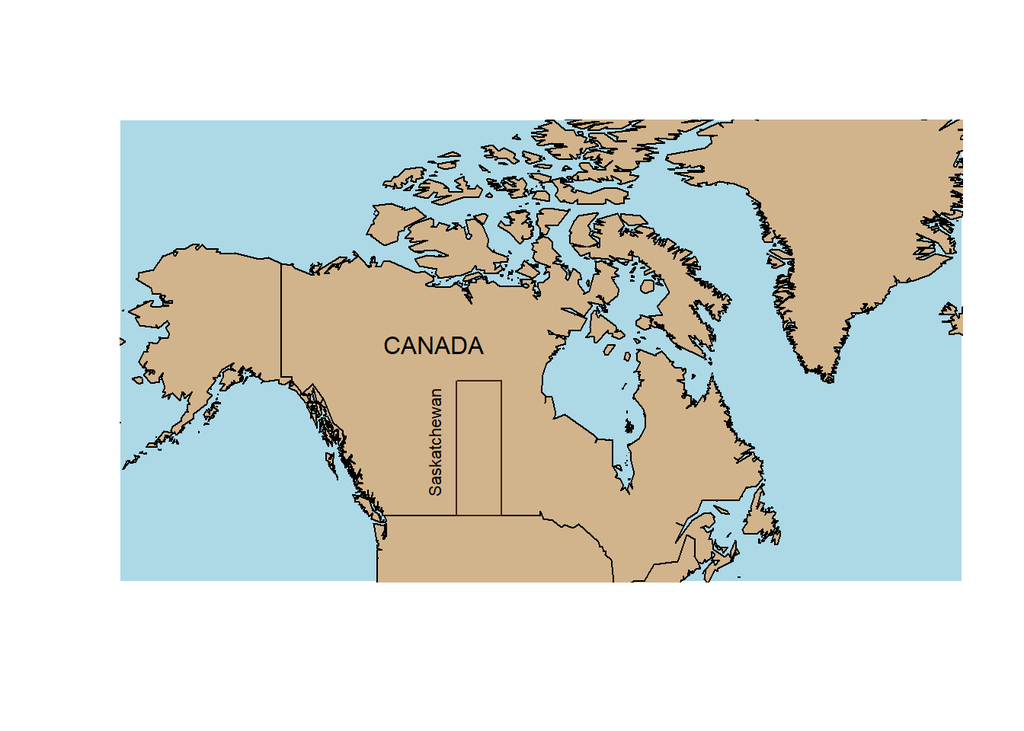

```r
plot(wrld_simpl,xlim=c(-130,-60),ylim=c(45,80),col='#D2B48C',bg='lightblue')
coords <- matrix(c(-110,-102,-102,-110,-110,60,60,49,49,60),ncol=2)
l <- Line(coords)
ls <- Lines(list(l),ID="1")
sls <- SpatialLines(list(ls))
df <- data.frame(province="Saskatchewan")
sldf <- SpatialLinesDataFrame(sls,df)
plot(sldf,add=T,col='#3d2402', cex=2)
text(-114, 55, 'Saskatchewan', srt=90, cex=0.7)
text(-114, 63, 'CANADA', cex=1)
```

- `SpatialPolygonesDataFrame` for plotting polygones

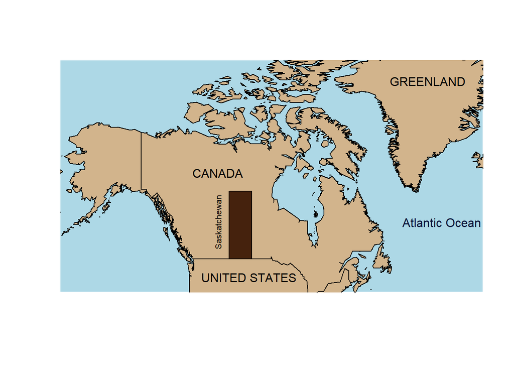

```r
plot(wrld_simpl,xlim=c(-130,-60),ylim=c(45,80),col='#D2B48C',bg='lightblue')
coords <- matrix(c(-110,-102,-102,-110,-110,60,60,49,49,60),ncol=2)
p <- Polygon(coords)
ps <- Polygons(list(p),ID="1")
sps <- SpatialPolygons(list(ps))
df <- data.frame(province="Saskatchewan")
spdf <- SpatialPolygonsDataFrame(sps,df)
plot(spdf,add=T,col='#45220d')
text(-114, 55, 'Saskatchewan', srt=90, cex=0.7)
text(-114, 63, 'CANADA', cex=1)
text(-103, 46, 'UNITED STATES', cex=1)
text(-40, 78, 'GREENLAND', cex=1)
text(-35, 55, 'Atlantic Ocean', cex=1, col='#071238')
```

## Map improvement: `raster`

Spatial data: download, unzip, and import spatial shape (don’t forget to set up your working directory). Those spataial data are higher resolution spatial data at teh country level.

```r
download.file("https://www.dipintothereef.com/uploads/3/7/3/5/37359245/twn_adm.zip", destfile="Data/taiwan_shape.zip") # download file
unzip('taiwan_shape.zip',exdir="Data/taiwan_shape_unzip") # unzip it
taiwan <- readOGR(dsn = "Data/taiwan_shape_unzip",layer = "TWN_adm0")
# can also sf::st_read in order to read data
```

Plot the map of the whole country:

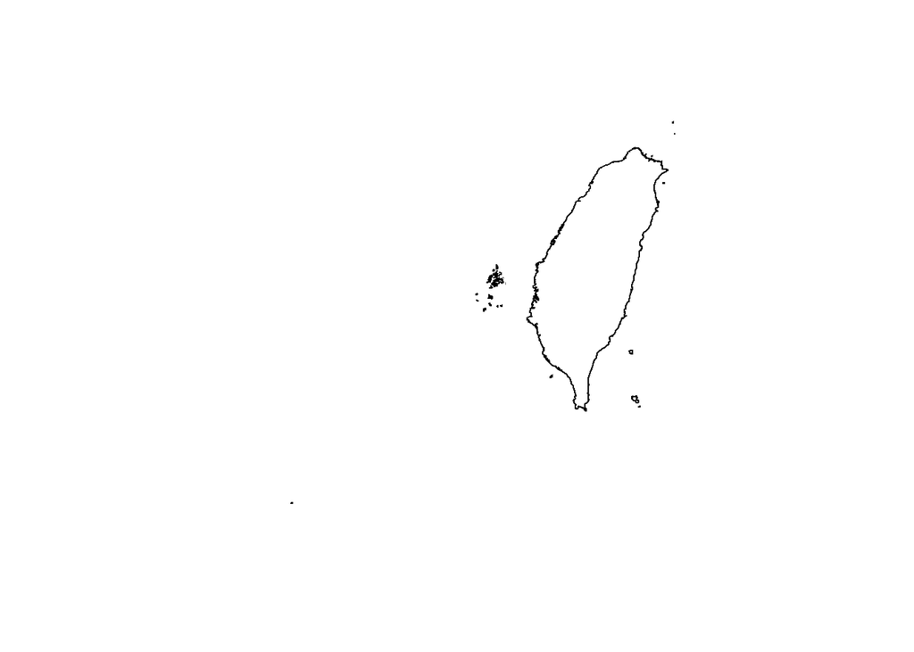

```r
plot (taiwan) # simple naked map
```

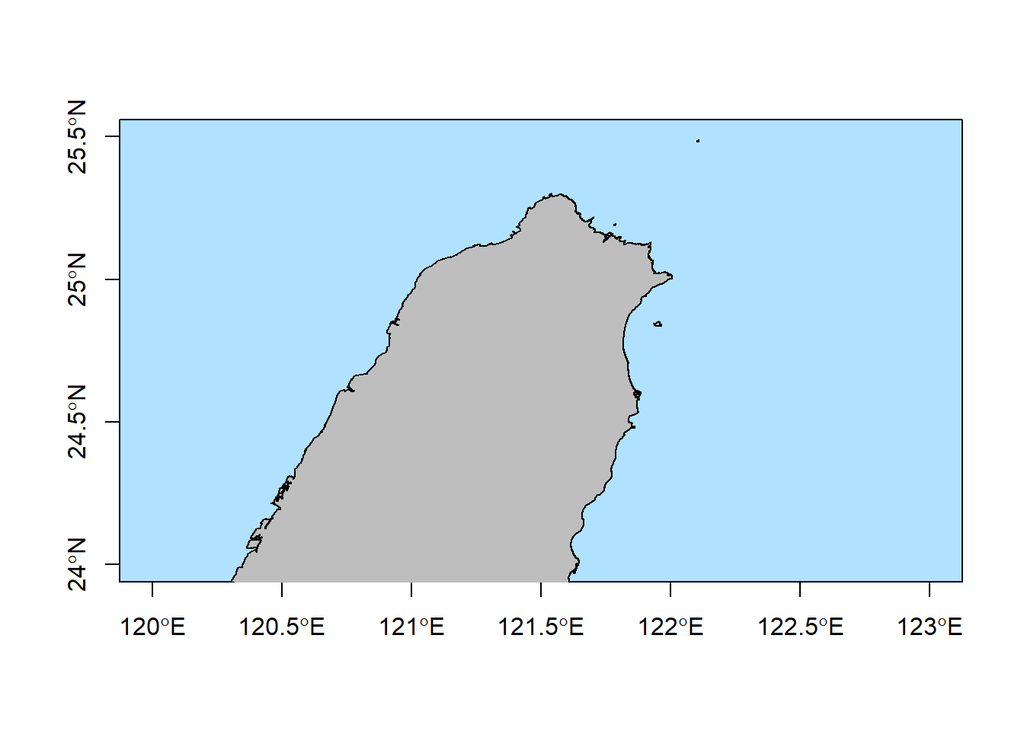

```r
plot (taiwan, axes=T, xlim=c(121,122), ylim=c(24,25.5), bg=colors()[431],col='grey') # add colors
```

```r
library(raster)
```

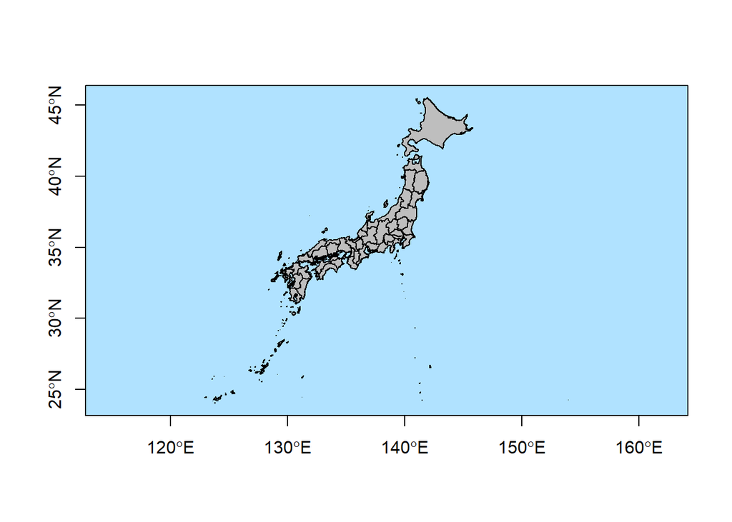

```r
TWN <- getData('GADM', country="TWN", level=1) # data Taiwan
JPN <- getData('GADM', country="JPN", level=1) # data Japan
plot(JPN,axes=T,bg=colors()[431],col='grey')
```

We can examined the object `TWN`

```r
class(TWN) # SpatialPolygonsDataFrame
TWN$NAME_1 # gives the names of the provinces, incomplete in TW
```

[output not shown]

And plot individual province as:

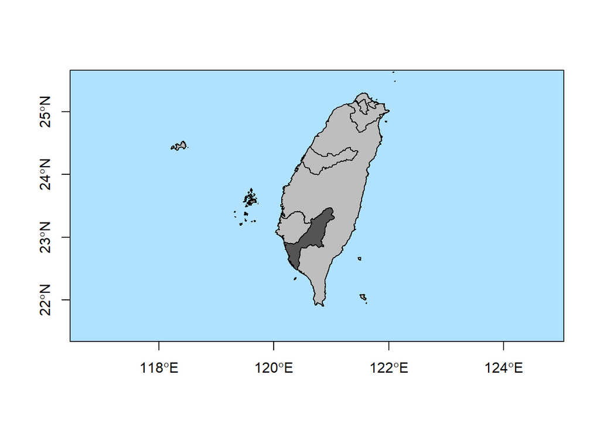

```r
plot(TWN,col="grey",xlim=c(119,122.5), ylim=c(21.5,25.5), bg=colors()[431], axes=T)
KAO <- TWN[TWN$NAME_1=="Kaohsiung",]
plot(KAO,col="gray 33",add=TRUE)
```

Random customization of our map (e.g. adding population)

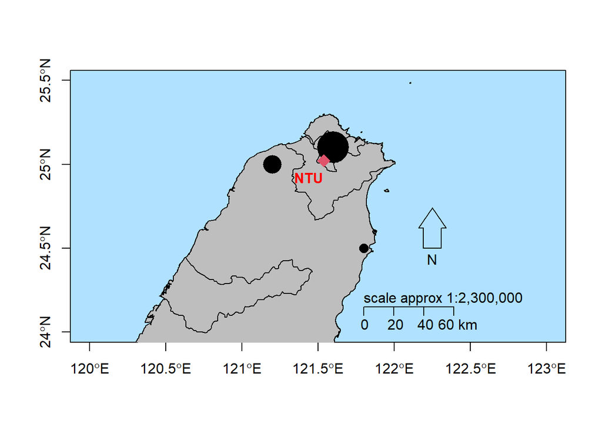

```r
plot(TWN,col="grey",xlim=c(121,122), ylim=c(24,25.5), bg=colors()[431], axes=T)
coords <- matrix(cbind(lon=c(121.2,121.6,121.8),lat=c(25,25.1,24.5)),ncol=2)
coords <- coordinates(coords)
spoints <- SpatialPoints(coords)
df <- data.frame(location=c("City 1","City 2","City 3"),pop=c(138644,390095,34562))
spointsdf <- SpatialPointsDataFrame(spoints,df)
scalefactor <- sqrt(spointsdf$pop)/sqrt(max(spointsdf$pop))
plot(spointsdf,add=TRUE,col='black',pch=16,cex=scalefactor*5)
# add location of NTU
points(121.537290,25.021335, type="p", pch=18, col=2, cex=2)
# add text
text(121.437290,24.921335,"NTU", col='red', font=2)
# add scale
maps::map.scale(x=121.8, y=24.15)
# add north arrow
GISTools::north.arrow(xb=122.25,yb=24.5, len=0.06, lab='N')
```